# Practical 1 — Airline Passengers

**1. Effect of sample size (n):** - Small: histogram looks noisy, deviates from the red theoretical density line. Line plot shows more spikes, more irregular. - High: histogram matches more closely the theoretical normal distribution, line plot still sows random pattern.

**2. Effect of mean (mu):** - Changing the mean shifts the center of the histogram and line plot. If mu -> 0, centered around 0. Overall shape and spread is the same.

**3. Effects of Standard Deviation (sigma):** - Increasing sigma spreads the data: values more dispersed in the line plot, and histogram becomes wider and flatter. - Decreasing sigma concentrates the data around the mean: narrower and taller histogram.

### Random seed

The reproduce the same random sample every time, we can set a seed. By default R uses a random seed.

```r
m <- 1
set.seed(m)
w <- rnorm(1000)
w
```

[output not shown]

[output cut: 185 more lines]

### Comparison of samples from the underlying population

Overlay the theoretical normal density on the histogram:

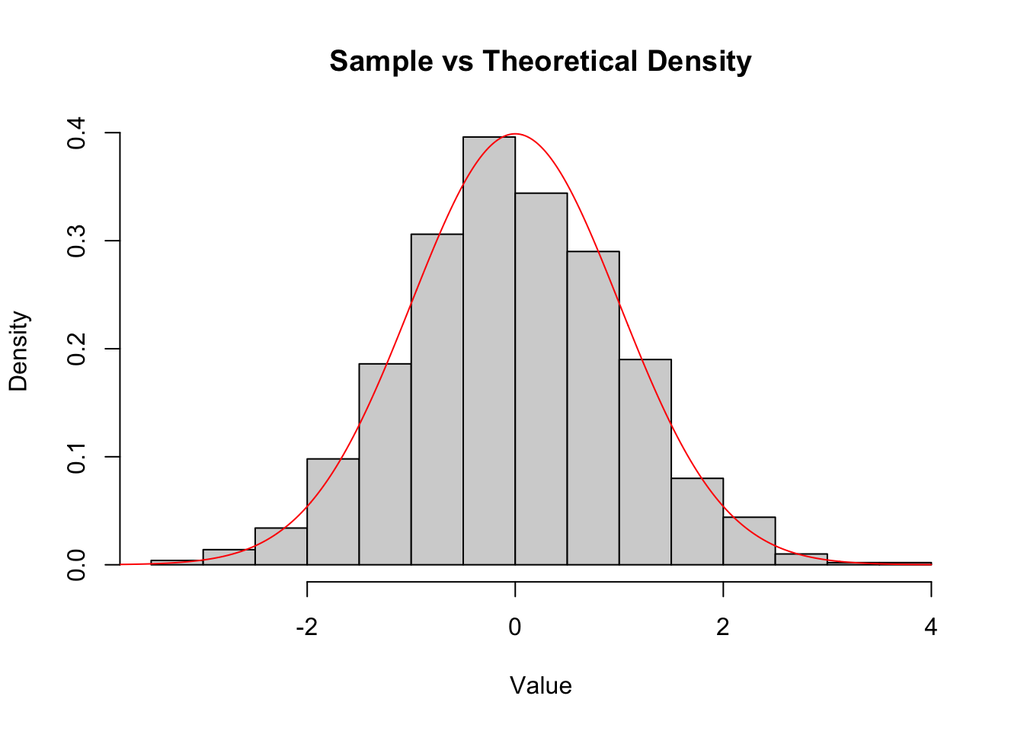

```r
n <- 1000
x <- seq(-4, 4, length = 1000)

hist(rnorm(n), prob = TRUE, main = "Sample vs Theoretical Density", xlab = "Value")
points(x, dnorm(x), type = "l", col = "red")
```

And autocorrelation function (ACF) for IID Gaussian noise:

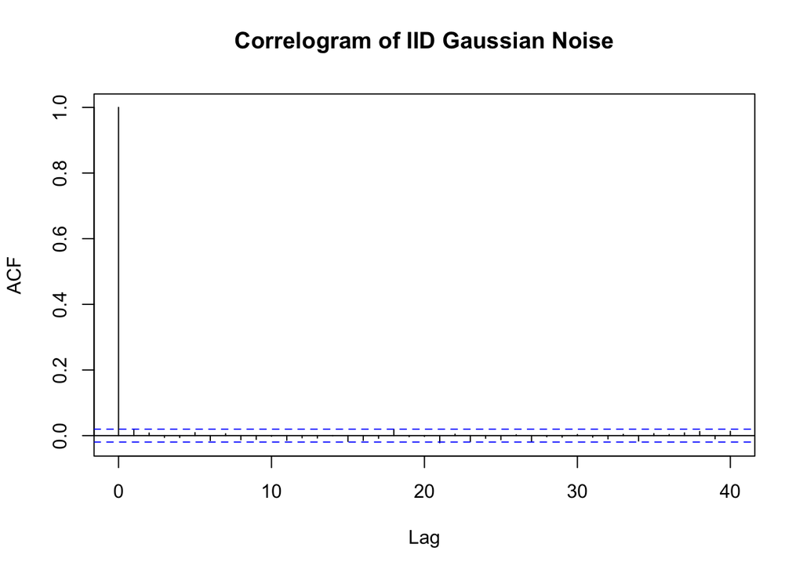

```r
N <- 10000
mu <- 5
sigma <- 2
z <- rnorm(N, mean = mu, sd = sigma)
acf(z, main = "Correlogram of IID Gaussian Noise")
```

As we are working with IID noise, the ACF shows no significant correlation -> independence between observations.

## 10. Random walk (exercise 1b.2)

### Random walk trajectory

The plot of rw <- cumsum(z_rw) shows a walk that fluctuates randomly over time. There is no stationary mean, a key property of random walk: variance increases with time.

### Different seeds

Different seeds produce different trajectories. Each trajectory is a random walk. Overall, shape looks similar showing that random walks are statistically consistent. With same the seed we obtain the same trajectory, this demostrates reproducibility.

### Larger radom walk

The iterative constructio of x_alt with 10000 points produces a longer and smoother path, but still shows random fluctuations. Range of values grows larger with more steps. Variance accumulates over time.

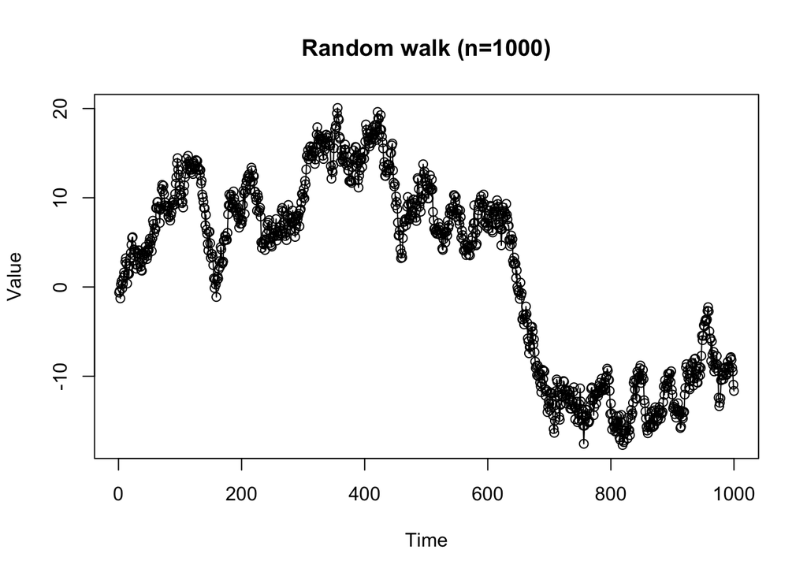

```r
# simulate a simple random walk and inspect trajectory and differences
n <- 1000
set.seed(1)
z_rw <- rnorm(n)
rw <- cumsum(z_rw)
plot(rw, type = "o", main = "Random walk (n=1000)", xlab = "Time", ylab = "Value")
```

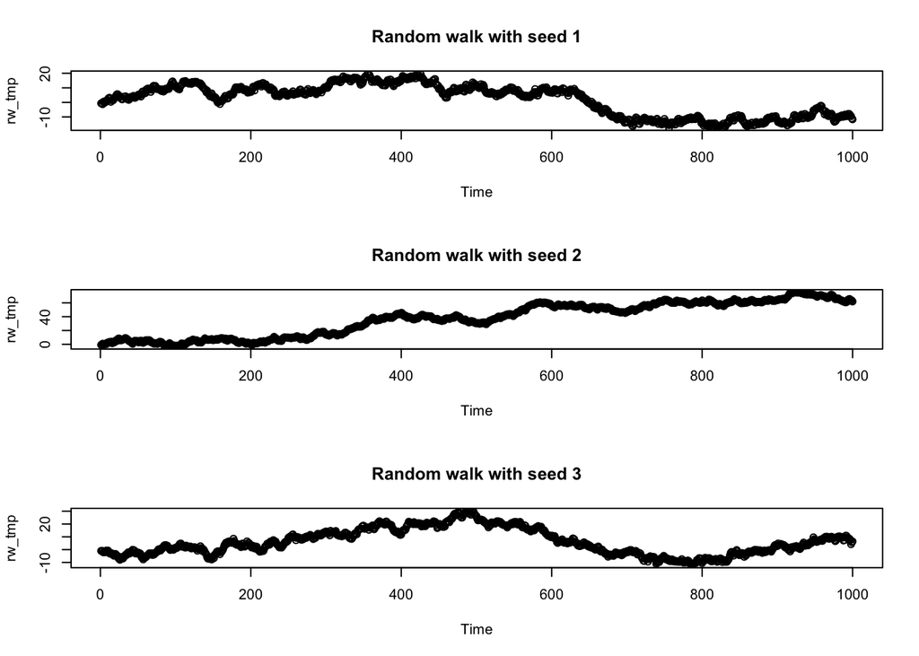

```r
# replicate with different seeds in a 3-row layout
layout(matrix(1:3, nrow = 3))
for (m in 1:3) {
  set.seed(m)
  z_tmp <- rnorm(n)
  rw_tmp <- cumsum(z_tmp)
  plot(rw_tmp, type = "o", main = paste("Random walk with seed", m), xlab = "Time")
}
```

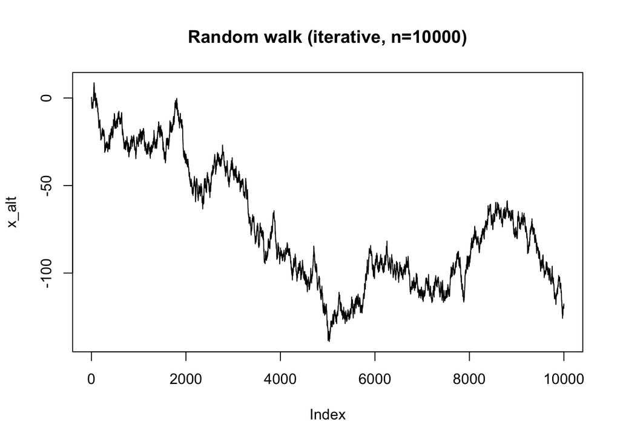

```r
layout(1)

# alternative construction (iterative) for larger n
n2 <- 10000
w <- rnorm(n2)
x_alt <- numeric(n2)
x_alt[1] <- w[1]
for (t in 2:n2) x_alt[t] <- x_alt[t-1] + w[t]
plot(x_alt, type = "l", main = "Random walk (iterative, n=10000)")
```

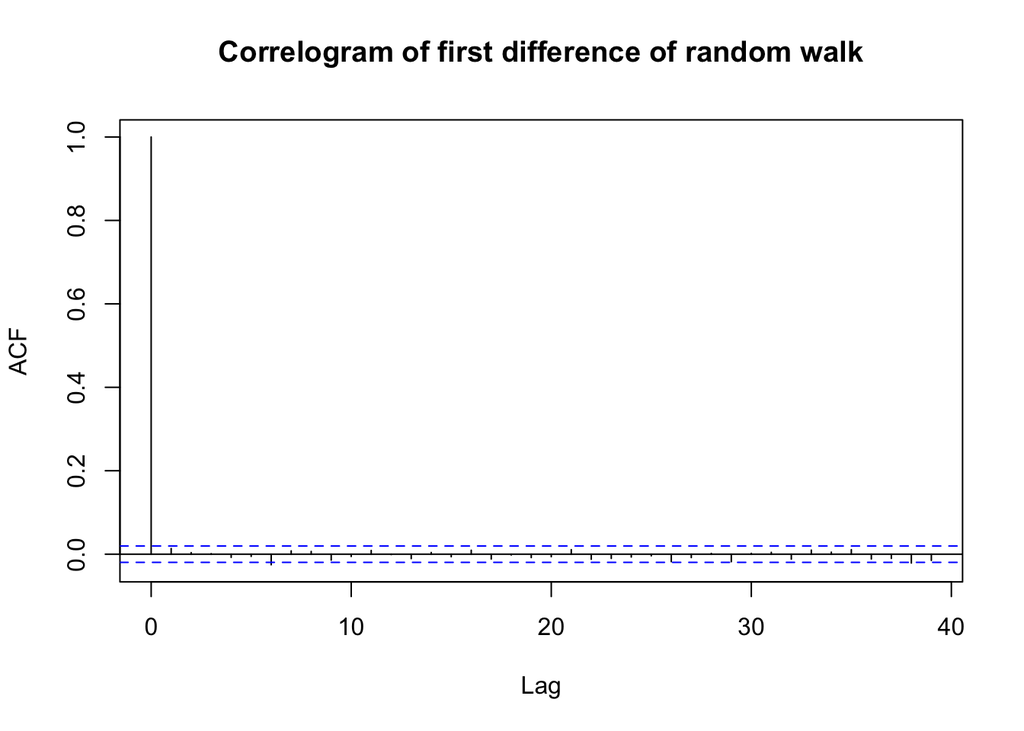

```r
# first difference of a random walk is (approximately) iid noise
acf(diff(x_alt), main = "Correlogram of first difference of random walk")
```

### First differences

Taking the first difference of a random walk (diff(x_alt)) removes the drift and produces a series that approximates IID Gaussian noise. The correlogram shows no significant autocorrelation.

A key property of random walks is that they are integrated of order 1 (I(1)). This means that the first differences gives a stationary series.